# CS 422 - Homework 6

Imaduddin Sheikh

###### Due Date: Wednesday, Mar 30 2022 11:59:59 PM Chicago Time [Extension Requested]

### 2. Practicum Problems

### 2.1. Association Rules

```r
setwd("~/Homework 6")
library(arules)
```

### Part 2.1(a)

```r
products.df <- read.csv("products.csv", header = FALSE)
tr1.df <- read.transactions("tr-1k.csv", format = 'basket', cols = c(1), header = FALSE, sep = ',')
write(tr1.df, "tr-1k-canonical.csv")
tr1.trans <- read.csv("tr-1k-canonical.csv", header = FALSE, col.names = c("items"))
tr1.canonical.df <- (apply(tr1.trans, 1, replacement.function))
write(tr1.canonical.df, "tr-1k-canonical.csv")
```

```r
tr1.df <- read.transactions("tr-1k.csv", format = 'basket', cols = c(1), header = FALSE, sep = ',')
write(tr1.df, "tr-1k-canonical.csv")
tr1.trans <- read.csv("tr-1k-canonical.csv", header = FALSE, col.names = c("items"))
tr1.canonical.df <- (apply(tr1.trans, 1, replacement.function))
write(tr1.canonical.df, "tr-1k-canonical.csv")
```

```r
# tr5.df <- read.transactions("tr-5k.csv", format = 'basket', cols = c(1), header = FALSE, sep = ',')
# write(tr5.df, "tr-5k-canonical.csv")
# tr5.trans <- read.csv("tr-5k-canonical.csv", header = FALSE, col.names = c("items"))
# tr5.canonical.df <- (apply(tr5.trans, 1, replacement.function))
# write(tr5.canonical.df, "tr-5k-canonical.csv")
```

```r
# tr20.df <- read.transactions("tr-20k.csv", format = 'basket', cols = c(1), header = FALSE, sep = ',')
# write(tr20.df, "tr-20k-canonical.csv")
# tr20.trans <- read.csv("tr-20k-canonical.csv", header = FALSE, col.names = c("items"))
# tr20.canonical.df <- (apply(tr20.trans, 1, replacement.function))
# write(tr20.canonical.df, "tr-20k-canonical.csv")
```

```r
tr75.df <- read.transactions("tr-75k.csv", format = 'basket', cols = c(1), header = FALSE, sep = ',')
write(tr75.df, "tr-75k-canonical.csv")
tr75.trans <- read.csv("tr-75k-canonical.csv", header = FALSE, col.names = c("items"))
tr75.canonical.df <- (apply(tr75.trans, 1, replacement.function))
write(tr75.canonical.df, "tr-75k-canonical.csv")
```

### Part 2.1(b)

```r
tr1k.df <- read.transactions("tr-1k-canonical.csv",format = 'basket', header = FALSE, sep = ',')
tr5k.df <- read.transactions("tr-5k-canonical.csv",format = 'basket', header = FALSE, sep = ',')
tr20k.df <- read.transactions("tr-20k-canonical.csv",format = 'basket', header = FALSE, sep = ',')
tr75k.df <- read.transactions("tr-75k-canonical.csv",format = 'basket', header = FALSE, sep = ',')
```

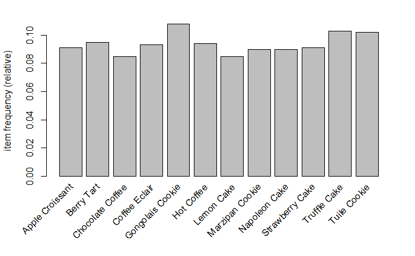

```r
itemFrequencyPlot(tr1k.df, support = 0.085)
```

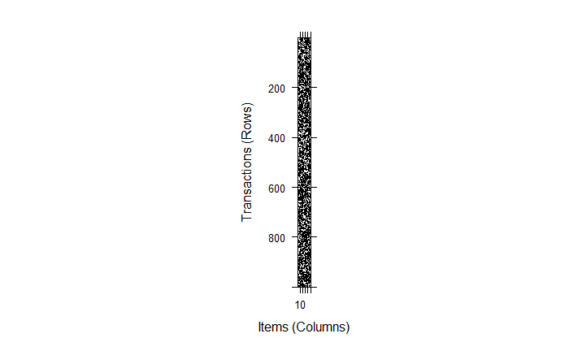

```r
image(tr1k.df)
```

```r
rules.1k <- apriori(tr1k.df, parameter=list(support=0.05, target="frequent itemsets"))
```

```
Apriori

Parameter specification:
```

|  | confidence | minval | smax | arem | aval | originalSupport | maxtime | support | minlen | maxlen | target | ext |
| --- | --- | --- | --- | --- | --- | --- | --- | --- | --- | --- | --- | --- |
|  | NA | 0.1 | 1 | none | FALSE | TRUE | 5 | 0.05 | 1 | 10 | frequent itemsets | TRUE |

```
Algorithmic control:
```

|  | filter | tree | heap | memopt | load | sort | verbose |
| --- | --- | --- | --- | --- | --- | --- | --- |
|  | 0.1 | TRUE | TRUE | FALSE | TRUE | 2 | TRUE |

```
Absolute minimum support count: 50

set item appearances ...[0 item(s)] done [0.00s].
set transactions ...[50 item(s), 1000 transaction(s)] done [0.00s].
sorting and recoding items ... [40 item(s)] done [0.00s].
creating transaction tree ... done [0.00s].
checking subsets of size 1 2 done [0.00s].
sorting transactions ... done [0.00s].
writing ... [42 set(s)] done [0.00s].
creating S4 object  ... done [0.00s].
```

```r
inspect(head(rules.1k, by="support", 15))
```

|  | items | support | count |
| --- | --- | --- | --- |
| [1] | {Gongolais Cookie} | 0.108 | 108 |
| [2] | {Truffle Cake} | 0.103 | 103 |
| [3] | {Tuile Cookie} | 0.102 | 102 |
| [4] | {Berry Tart} | 0.095 | 95 |
| [5] | {Hot Coffee} | 0.094 | 94 |
| [6] | {Coffee Eclair} | 0.093 | 93 |
| [7] | {Strawberry Cake} | 0.091 | 91 |
| [8] | {Apple Croissant} | 0.091 | 91 |
| [9] | {Marzipan Cookie} | 0.090 | 90 |
| [10] | {Napoleon Cake} | 0.090 | 90 |

[output cut: 5 more lines]

After trying out different *minconf* values on the algorithm, I found that the data set with the 1000 transactions does not have any item set that has support greater than 0.108.  
With the help of the code snippet above, here are 10 of the item sets with the highest support. This does justice to the histogram for the highest supported item sets in the 1000 transactions.

```r
rules.1k <- apriori(tr1k.df, parameter=list(support=0.01, confidence = 0.95, target="rules"))
```

```
Apriori

Parameter specification:
```

|  | confidence | minval | smax | arem | aval | originalSupport | maxtime | support | minlen | maxlen | target | ext |
| --- | --- | --- | --- | --- | --- | --- | --- | --- | --- | --- | --- | --- |
|  | 0.95 | 0.1 | 1 | none | FALSE | TRUE | 5 | 0.01 | 1 | 10 | rules | TRUE |

```
Algorithmic control:
```

|  | filter | tree | heap | memopt | load | sort | verbose |
| --- | --- | --- | --- | --- | --- | --- | --- |
|  | 0.1 | TRUE | TRUE | FALSE | TRUE | 2 | TRUE |

```
Absolute minimum support count: 10

set item appearances ...[0 item(s)] done [0.00s].
set transactions ...[50 item(s), 1000 transaction(s)] done [0.00s].
sorting and recoding items ... [50 item(s)] done [0.00s].
creating transaction tree ... done [0.00s].
checking subsets of size 1 2 3 4 5 done [0.00s].
writing ... [50 rule(s)] done [0.00s].
creating S4 object  ... done [0.00s].
```

```r
inspect(head(rules.1k, by="lift", 15))
```

|  | lhs |  | rhs | support | confidence | coverage | lift | count |
| --- | --- | --- | --- | --- | --- | --- | --- | --- |
| [1] | {Vanilla Frappuccino, Walnut Cookie} | => | {Chocolate Tart} | 0.018 | 1.0000000 | 0.018 | 19.60784 | 18 |
| [2] | {Apple Pie, Coffee Eclair, Hot Coffee} | => | {Almond Twist} | 0.024 | 1.0000000 | 0.024 | 15.38462 | 24 |
| [3] | {Raspberry Cookie, Raspberry Lemonade} | => | {Lemon Cookie} | 0.029 | 1.0000000 | 0.029 | 15.15152 | 29 |
| [4] | {Green Tea, Lemon Lemonade, Raspberry Lemonade} | => | {Lemon Cookie} | 0.019 | 1.0000000 | 0.019 | 15.15152 | 19 |
| [5] | {Green Tea, Lemon Cookie, Raspberry Lemonade} | => | {Lemon Lemonade} | 0.019 | 1.0000000 | 0.019 | 15.15152 | 19 |
| [6] | {Green Tea, Lemon Lemonade, Raspberry Cookie} | => | {Lemon Cookie} | 0.019 | 1.0000000 | 0.019 | 15.15152 | 19 |
| [7] | {Green Tea, Lemon Cookie, Raspberry Cookie} | => | {Lemon Lemonade} | 0.019 | 1.0000000 | 0.019 | 15.15152 | 19 |
| [8] | {Green Tea, Raspberry Cookie, Raspberry Lemonade} | => | {Lemon Lemonade} | 0.019 | 1.0000000 | 0.019 | 15.15152 | 19 |
| [9] | {Lemon Lemonade, Raspberry Cookie, Raspberry Lemonade} | => | {Lemon Cookie} | 0.028 | 1.0000000 | 0.028 | 15.15152 | 28 |
| [10] | {Green Tea, Raspberry Cookie, Raspberry Lemonade} | => | {Lemon Cookie} | 0.019 | 1.0000000 | 0.019 | 15.15152 | 19 |

[output cut: 5 more lines]

The association rules above provide a general picture of the 1000 transactions recorded. In this data set, some interesting rules can be found. One being that customers who bought Vanilla Frappuccino and Walnut Cookie were very likely to buy Chocolate Tart. A very high lift value and low support value supports this fact.

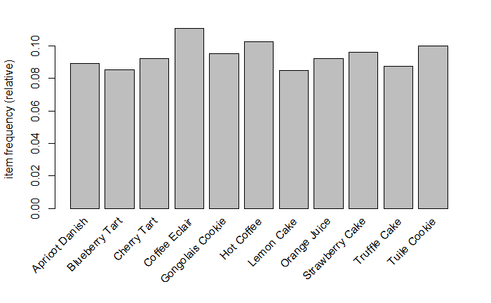

```r
itemFrequencyPlot(tr5k.df, support = 0.085)
```

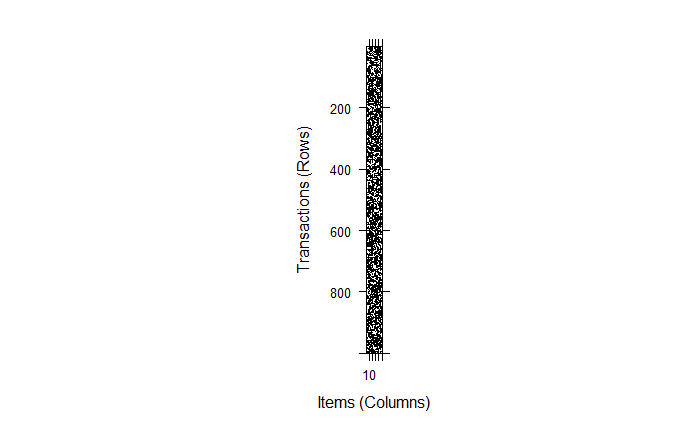

```r
image(tr1k.df)
```

```r
rules.5k <- apriori(tr5k.df, parameter=list(support=0.05, target="frequent itemsets"))
```

```
Apriori

Parameter specification:
```

|  | confidence | minval | smax | arem | aval | originalSupport | maxtime | support | minlen | maxlen | target | ext |
| --- | --- | --- | --- | --- | --- | --- | --- | --- | --- | --- | --- | --- |
|  | NA | 0.1 | 1 | none | FALSE | TRUE | 5 | 0.05 | 1 | 10 | frequent itemsets | TRUE |

```
Algorithmic control:
```

|  | filter | tree | heap | memopt | load | sort | verbose |
| --- | --- | --- | --- | --- | --- | --- | --- |
|  | 0.1 | TRUE | TRUE | FALSE | TRUE | 2 | TRUE |

```
Absolute minimum support count: 250

set item appearances ...[0 item(s)] done [0.00s].
set transactions ...[50 item(s), 5000 transaction(s)] done [0.01s].
sorting and recoding items ... [38 item(s)] done [0.00s].
creating transaction tree ... done [0.00s].
checking subsets of size 1 2 done [0.00s].
sorting transactions ... done [0.00s].
writing ... [39 set(s)] done [0.00s].
creating S4 object  ... done [0.00s].
```

```r
inspect(head(rules.5k, by="support", 15))
```

|  | items | support | count |
| --- | --- | --- | --- |
| [1] | {Coffee Eclair} | 0.1108 | 554 |
| [2] | {Hot Coffee} | 0.1026 | 513 |
| [3] | {Tuile Cookie} | 0.0998 | 499 |
| [4] | {Strawberry Cake} | 0.0960 | 480 |
| [5] | {Gongolais Cookie} | 0.0954 | 477 |
| [6] | {Orange Juice} | 0.0922 | 461 |
| [7] | {Cherry Tart} | 0.0920 | 460 |
| [8] | {Apricot Danish} | 0.0892 | 446 |
| [9] | {Truffle Cake} | 0.0876 | 438 |
| [10] | {Blueberry Tart} | 0.0852 | 426 |

[output cut: 5 more lines]

Coffee Eclair, Hot Coffee and Tuile Cookie(also Strawberry Cake) have overtaken Gongolais Cookie in this data set which is evident by larger support values.

```r
rules.5k <- apriori(tr5k.df, parameter=list(support=0.01, confidence = 0.95, target="rules"))
```

```
Apriori

Parameter specification:
```

|  | confidence | minval | smax | arem | aval | originalSupport | maxtime | support | minlen | maxlen | target | ext |
| --- | --- | --- | --- | --- | --- | --- | --- | --- | --- | --- | --- | --- |
|  | 0.95 | 0.1 | 1 | none | FALSE | TRUE | 5 | 0.01 | 1 | 10 | rules | TRUE |

```
Algorithmic control:
```

|  | filter | tree | heap | memopt | load | sort | verbose |
| --- | --- | --- | --- | --- | --- | --- | --- |
|  | 0.1 | TRUE | TRUE | FALSE | TRUE | 2 | TRUE |

```
Absolute minimum support count: 50

set item appearances ...[0 item(s)] done [0.00s].
set transactions ...[50 item(s), 5000 transaction(s)] done [0.00s].
sorting and recoding items ... [50 item(s)] done [0.00s].
creating transaction tree ... done [0.00s].
checking subsets of size 1 2 3 4 5 done [0.01s].
writing ... [28 rule(s)] done [0.00s].
creating S4 object  ... done [0.00s].
```

```r
inspect(head(rules.5k, by="lift", 15))
```

|  | lhs |  | rhs | support | confidence | coverage | lift | count |
| --- | --- | --- | --- | --- | --- | --- | --- | --- |
| [1] | {Green Tea, Lemon Lemonade, Raspberry Lemonade} | => | {Raspberry Cookie} | 0.0212 | 1.0000000 | 0.0212 | 15.62500 | 106 |
| [2] | {Green Tea, Lemon Cookie, Raspberry Lemonade} | => | {Raspberry Cookie} | 0.0212 | 1.0000000 | 0.0212 | 15.62500 | 106 |
| [3] | {Green Tea, Lemon Cookie, Lemon Lemonade, Raspberry Lemonade} | => | {Raspberry Cookie} | 0.0212 | 1.0000000 | 0.0212 | 15.62500 | 106 |
| [4] | {Green Tea, Lemon Lemonade, Raspberry Cookie} | => | {Lemon Cookie} | 0.0212 | 1.0000000 | 0.0212 | 15.57632 | 106 |
| [5] | {Green Tea, Lemon Lemonade, Raspberry Lemonade} | => | {Lemon Cookie} | 0.0212 | 1.0000000 | 0.0212 | 15.57632 | 106 |
| [6] | {Green Tea, Raspberry Cookie, Raspberry Lemonade} | => | {Lemon Cookie} | 0.0212 | 1.0000000 | 0.0212 | 15.57632 | 106 |
| [7] | {Lemon Lemonade, Raspberry Cookie, Raspberry Lemonade} | => | {Lemon Cookie} | 0.0262 | 1.0000000 | 0.0262 | 15.57632 | 131 |
| [8] | {Green Tea, Lemon Lemonade, Raspberry Cookie, Raspberry Lemonade} | => | {Lemon Cookie} | 0.0212 | 1.0000000 | 0.0212 | 15.57632 | 106 |
| [9] | {Lemon Cookie, Lemon Lemonade, Raspberry Lemonade} | => | {Raspberry Cookie} | 0.0262 | 0.9924242 | 0.0264 | 15.50663 | 131 |
| [10] | {Green Tea, Lemon Cookie, Lemon Lemonade} | => | {Raspberry Cookie} | 0.0212 | 0.9906542 | 0.0214 | 15.47897 | 106 |

[output cut: 5 more lines]

The association rules above show that Lemon lemonades and cookies go very highly and likely with raspberry cookies and lemonade, with the help of green teas.

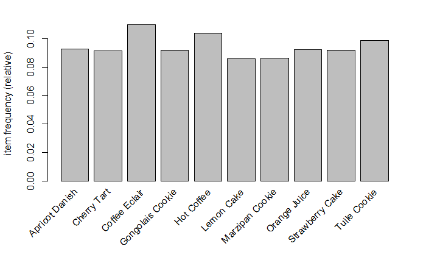

```r
itemFrequencyPlot(tr20k.df, support = 0.085)
```

[figure not shown]

```r
image(tr20k.df)
```

```r
rules.20k <- apriori(tr20k.df, parameter=list(support=0.05, target="frequent itemsets"))
```

```
Apriori

Parameter specification:
```

|  | confidence | minval | smax | arem | aval | originalSupport | maxtime | support | minlen | maxlen | target | ext |
| --- | --- | --- | --- | --- | --- | --- | --- | --- | --- | --- | --- | --- |
|  | NA | 0.1 | 1 | none | FALSE | TRUE | 5 | 0.05 | 1 | 10 | frequent itemsets | TRUE |

```
Algorithmic control:
```

|  | filter | tree | heap | memopt | load | sort | verbose |
| --- | --- | --- | --- | --- | --- | --- | --- |
|  | 0.1 | TRUE | TRUE | FALSE | TRUE | 2 | TRUE |

```
Absolute minimum support count: 1000

set item appearances ...[0 item(s)] done [0.00s].
set transactions ...[50 item(s), 20000 transaction(s)] done [0.02s].
sorting and recoding items ... [38 item(s)] done [0.00s].
creating transaction tree ... done [0.01s].
checking subsets of size 1 2 done [0.00s].
sorting transactions ... done [0.01s].
writing ... [39 set(s)] done [0.02s].
creating S4 object  ... done [0.00s].
```

```r
inspect(head(rules.20k, by="support", 15))
```

|  | items | support | count |
| --- | --- | --- | --- |
| [1] | {Coffee Eclair} | 0.10985 | 2197 |
| [2] | {Hot Coffee} | 0.10360 | 2072 |
| [3] | {Tuile Cookie} | 0.09865 | 1973 |
| [4] | {Apricot Danish} | 0.09270 | 1854 |
| [5] | {Orange Juice} | 0.09240 | 1848 |
| [6] | {Strawberry Cake} | 0.09200 | 1840 |
| [7] | {Gongolais Cookie} | 0.09185 | 1837 |
| [8] | {Cherry Tart} | 0.09125 | 1825 |
| [9] | {Marzipan Cookie} | 0.08645 | 1729 |
| [10] | {Lemon Cake} | 0.08600 | 1720 |

[output cut: 5 more lines]

There is not a significant result in the 20,000-transaction data set when compared with the products frequently found/bought in transactions in the data set with 5,000 transactions. COffee Eclair, Hot Coffee and Tuile Cookie were top 3 back there as well.

```r
rules.20k <- apriori(tr20k.df, parameter=list(support=0.01, confidence = 0.95, target="rules"))
```

```
Apriori

Parameter specification:
```

|  | confidence | minval | smax | arem | aval | originalSupport | maxtime | support | minlen | maxlen | target | ext |
| --- | --- | --- | --- | --- | --- | --- | --- | --- | --- | --- | --- | --- |
|  | 0.95 | 0.1 | 1 | none | FALSE | TRUE | 5 | 0.01 | 1 | 10 | rules | TRUE |

```
Algorithmic control:
```

|  | filter | tree | heap | memopt | load | sort | verbose |
| --- | --- | --- | --- | --- | --- | --- | --- |
|  | 0.1 | TRUE | TRUE | FALSE | TRUE | 2 | TRUE |

```
Absolute minimum support count: 200

set item appearances ...[0 item(s)] done [0.00s].
set transactions ...[50 item(s), 20000 transaction(s)] done [0.02s].
sorting and recoding items ... [50 item(s)] done [0.00s].
creating transaction tree ... done [0.01s].
checking subsets of size 1 2 3 4 5 done [0.01s].
writing ... [28 rule(s)] done [0.00s].
creating S4 object  ... done [0.01s].
```

```r
inspect(head(rules.20k, by="lift", 15))
```

|  | lhs |  | rhs | support | confidence | coverage | lift | count |
| --- | --- | --- | --- | --- | --- | --- | --- | --- |
| [1] | {Green Tea, Lemon Cookie, Raspberry Cookie, Raspberry Lemonade} | => | {Lemon Lemonade} | 0.02040 | 1.0000000 | 0.02040 | 15.02630 | 408 |
| [2] | {Green Tea, Raspberry Cookie, Raspberry Lemonade} | => | {Lemon Lemonade} | 0.02045 | 0.9975610 | 0.02050 | 14.98965 | 409 |
| [3] | {Green Tea, Lemon Cookie, Raspberry Lemonade} | => | {Lemon Lemonade} | 0.02045 | 0.9951338 | 0.02055 | 14.95318 | 409 |
| [4] | {Lemon Cookie, Raspberry Cookie, Raspberry Lemonade} | => | {Lemon Lemonade} | 0.02545 | 0.9941406 | 0.02560 | 14.93825 | 509 |
| [5] | {Green Tea, Lemon Cookie, Raspberry Cookie} | => | {Lemon Lemonade} | 0.02040 | 0.9927007 | 0.02055 | 14.91662 | 408 |
| [6] | {Apple Croissant, Apple Tart, Cherry Soda} | => | {Apple Danish} | 0.02100 | 0.9929078 | 0.02115 | 14.69886 | 420 |
| [7] | {Green Tea, Lemon Lemonade, Raspberry Cookie, Raspberry Lemonade} | => | {Lemon Cookie} | 0.02040 | 0.9975550 | 0.02045 | 14.61619 | 408 |
| [8] | {Green Tea, Lemon Cookie, Lemon Lemonade, Raspberry Cookie} | => | {Raspberry Lemonade} | 0.02040 | 1.0000000 | 0.02040 | 14.60920 | 408 |
| [9] | {Green Tea, Lemon Lemonade, Raspberry Lemonade} | => | {Lemon Cookie} | 0.02045 | 0.9951338 | 0.02055 | 14.58072 | 409 |
| [10] | {Green Tea, Raspberry Cookie, Raspberry Lemonade} | => | {Lemon Cookie} | 0.02040 | 0.9951220 | 0.02050 | 14.58054 | 408 |

[output cut: 5 more lines]

Again, there is not much of a surprise in the association rules of this data set. Raspberry lemonades and cookies are going well in lemon cookies and lemonade, green tea is also involved. However, one interesting rule came up. Customers who bought croissant and tarts of apple flavor, and cherry soda at the same time also bought apple danish. Non-perishable apple-flavored products went well together.

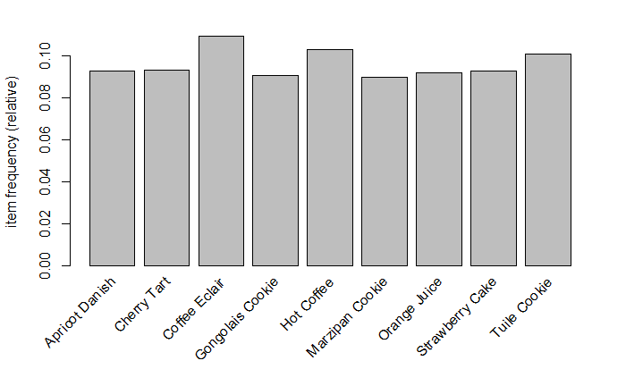

```r
itemFrequencyPlot(tr75k.df, support = 0.085)
```

[figure not shown]

```r
image(tr75k.df)
```

```r
rules.75k <- apriori(tr75k.df, parameter=list(support=0.05, target="frequent itemsets"))
```

```
Apriori

Parameter specification:
```

|  | confidence | minval | smax | arem | aval | originalSupport | maxtime | support | minlen | maxlen | target | ext |
| --- | --- | --- | --- | --- | --- | --- | --- | --- | --- | --- | --- | --- |
|  | NA | 0.1 | 1 | none | FALSE | TRUE | 5 | 0.05 | 1 | 10 | frequent itemsets | TRUE |

```
Algorithmic control:
```

|  | filter | tree | heap | memopt | load | sort | verbose |
| --- | --- | --- | --- | --- | --- | --- | --- |
|  | 0.1 | TRUE | TRUE | FALSE | TRUE | 2 | TRUE |

```
Absolute minimum support count: 3750

set item appearances ...[0 item(s)] done [0.00s].
set transactions ...[50 item(s), 75000 transaction(s)] done [0.04s].
sorting and recoding items ... [38 item(s)] done [0.00s].
creating transaction tree ... done [0.06s].
checking subsets of size 1 2 done [0.00s].
sorting transactions ... done [0.03s].
writing ... [40 set(s)] done [0.00s].
creating S4 object  ... done [0.01s].
```

```r
inspect(head(rules.75k, by="support", 15))
```

|  | items | support | count |
| --- | --- | --- | --- |
| [1] | {Coffee Eclair} | 0.10924000 | 8193 |
| [2] | {Hot Coffee} | 0.10266667 | 7700 |
| [3] | {Tuile Cookie} | 0.10074667 | 7556 |
| [4] | {Cherry Tart} | 0.09316000 | 6987 |
| [5] | {Strawberry Cake} | 0.09264000 | 6948 |
| [6] | {Apricot Danish} | 0.09257333 | 6943 |
| [7] | {Orange Juice} | 0.09161333 | 6871 |
| [8] | {Gongolais Cookie} | 0.09044000 | 6783 |
| [9] | {Marzipan Cookie} | 0.08977333 | 6733 |
| [10] | {Berry Tart} | 0.08482667 | 6362 |

[output cut: 5 more lines]

Same pattern of item set frequency as seen in the data sets with transactions of 5,000 and 20,000.

```r
rules.75k <- apriori(tr75k.df, parameter=list(support=0.01, confidence = 0.95, target="rules"))
```

```
Apriori

Parameter specification:
```

|  | confidence | minval | smax | arem | aval | originalSupport | maxtime | support | minlen | maxlen | target | ext |
| --- | --- | --- | --- | --- | --- | --- | --- | --- | --- | --- | --- | --- |
|  | 0.95 | 0.1 | 1 | none | FALSE | TRUE | 5 | 0.01 | 1 | 10 | rules | TRUE |

```
Algorithmic control:
```

|  | filter | tree | heap | memopt | load | sort | verbose |
| --- | --- | --- | --- | --- | --- | --- | --- |
|  | 0.1 | TRUE | TRUE | FALSE | TRUE | 2 | TRUE |

```
Absolute minimum support count: 750

set item appearances ...[0 item(s)] done [0.00s].
set transactions ...[50 item(s), 75000 transaction(s)] done [0.05s].
sorting and recoding items ... [50 item(s)] done [0.01s].
creating transaction tree ... done [0.06s].
checking subsets of size 1 2 3 4 5 done [0.02s].
writing ... [27 rule(s)] done [0.00s].
creating S4 object  ... done [0.01s].
```

```r
inspect(head(rules.75k, by="lift", 15))
```

|  | lhs |  | rhs | support | confidence | coverage | lift | count |
| --- | --- | --- | --- | --- | --- | --- | --- | --- |
| [1] | {Green Tea, Lemon Cookie, Lemon Lemonade, Raspberry Lemonade} | => | {Raspberry Cookie} | 0.02073333 | 1.0000000 | 0.02073333 | 14.78415 | 1555 |
| [2] | {Green Tea, Lemon Cookie, Lemon Lemonade, Raspberry Cookie} | => | {Raspberry Lemonade} | 0.02073333 | 1.0000000 | 0.02073333 | 14.76087 | 1555 |
| [3] | {Apple Danish, Apple Tart, Cherry Soda} | => | {Apple Croissant} | 0.02058667 | 0.9929260 | 0.02073333 | 14.75519 | 1544 |
| [4] | {Green Tea, Lemon Lemonade, Raspberry Lemonade} | => | {Raspberry Cookie} | 0.02074667 | 0.9974359 | 0.02080000 | 14.74624 | 1556 |
| [5] | {Lemon Cookie, Lemon Lemonade, Raspberry Lemonade} | => | {Raspberry Cookie} | 0.02556000 | 0.9973985 | 0.02562667 | 14.74569 | 1917 |
| [6] | {Green Tea, Lemon Cookie, Raspberry Cookie} | => | {Raspberry Lemonade} | 0.02073333 | 0.9980745 | 0.02077333 | 14.73245 | 1555 |
| [7] | {Green Tea, Lemon Cookie, Lemon Lemonade} | => | {Raspberry Cookie} | 0.02073333 | 0.9942455 | 0.02085333 | 14.69908 | 1555 |
| [8] | {Green Tea, Lemon Lemonade, Raspberry Cookie, Raspberry Lemonade} | => | {Lemon Cookie} | 0.02073333 | 0.9993573 | 0.02074667 | 14.69355 | 1555 |
| [9] | {Green Tea, Lemon Lemonade, Raspberry Cookie} | => | {Raspberry Lemonade} | 0.02074667 | 0.9942492 | 0.02086667 | 14.67599 | 1556 |
| [10] | {Green Tea, Lemon Cookie, Lemon Lemonade} | => | {Raspberry Lemonade} | 0.02073333 | 0.9942455 | 0.02085333 | 14.67593 | 1555 |

[output cut: 5 more lines]

Same association rules observed as in 20,000-transaction data set.

### Part 2.1(c)

In the 1000-transaction data set, the association rules formed from it weren’t that generalized as they were in the the latter data sets. In the 5000, 20000, and 75000-transaction data sets, we could observe with good lift value how customers tend to buy lemon and raspberry-flavored cookies and lemonade, with green tea. With the emergence of apple-flavored items, we can easily observe that the patterns/rules begin to seem robust/generalizable as more transactions are added in the equation.